# Kelly Hudson AFRE 891 Data Replication Project

Original Paper by Adam Komarek

2025-04-19

## Introduction:

This replication package contains 16 raw data .csv files, 1 raw data excel file, 17 R-scripts and a readMe file.

16 of the R-scripts are written with the purpose of cleaning and processing various portions of the raw data. The 17th R-script is a program that reads and runs each of the other 16 R-scripts to generate and save all figures from the study.

I did not use the master file for this project but included the code for it at the end of this document. The readMe file and comments within the master file explain how to use the program

While this replication package generates a total of 24 tables and figures, the paper itself displays only 5 figures and 3 tables. The names of the other tables and figures are listed at the end of this document but will not be rendered in the html file. The tables will need to be formatted using the code:

tablename <- data.frame(lapply(df, function(x) { if (is.character(x)) iconv(x, from = ““, to =”UTF-8”, sub = “byte”) else x }), stringsAsFactors = FALSE)

knitr::kable(tablename, “pipe”)

to knit and display in a presentable maner

The replication process is for this paper is simple. Other than formatting the tables, the only addition I had to make to the code was to add a section at the end to print each figure.

Each of the following sections contains one of the R-script files from the replication package with the original comments.

The packages used for replication are found in the setup code chunk. Some packages (zoo, readxl, RColorBrewer, sf, rnaturalearth, and viridis) may need to be installed prior to running the replication code.

Link to paper: https://doi.org/10.1016/j.gloenvcha.2021.102343

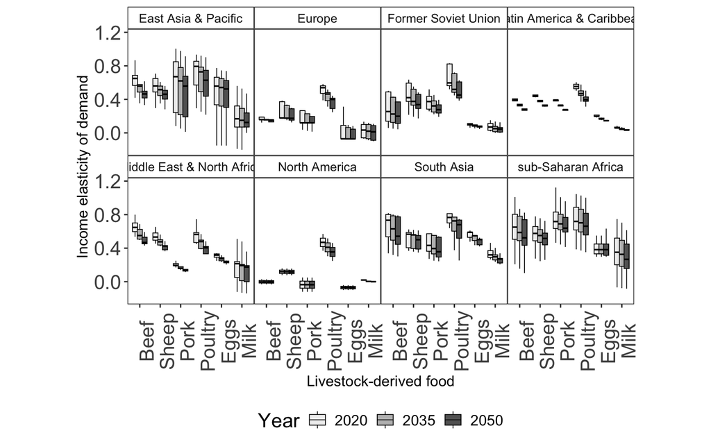

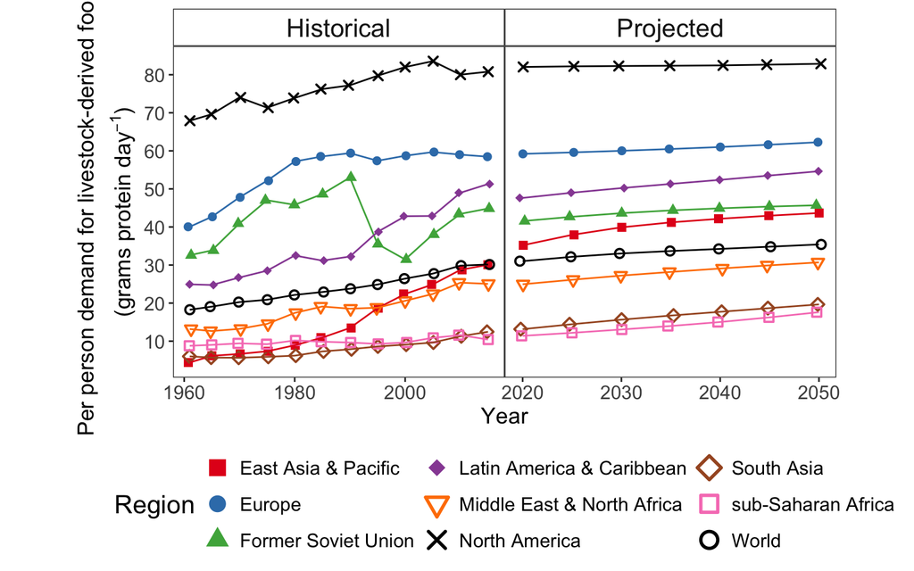

[figure not shown]

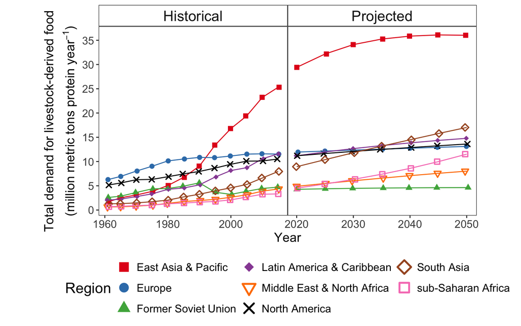

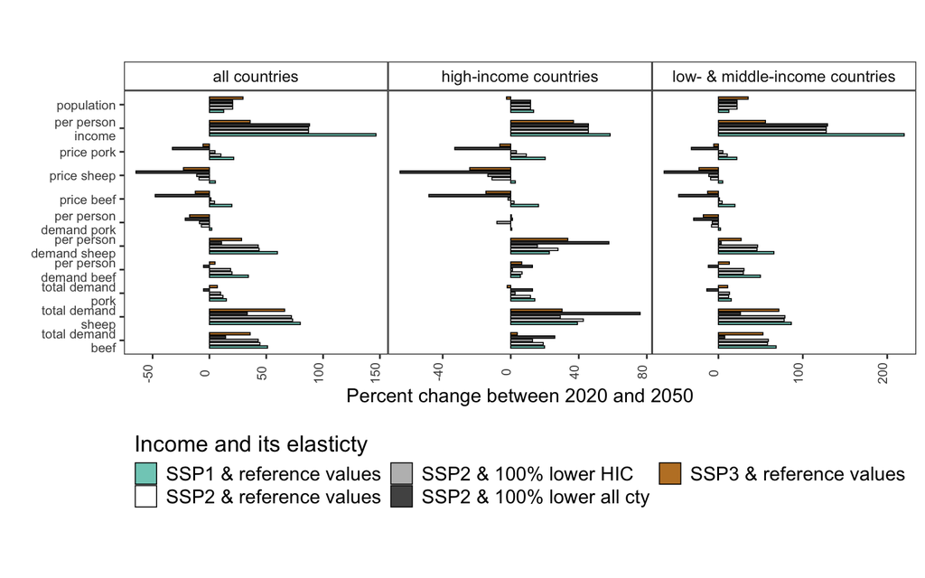

| scen | pPInc | pop |
| --- | --- | --- |
| SSP1_ref | 3.05 (-0.02<96>9.99, 2.94) | 0.4 (-1.34<96>2.08, 0.81) |
| SSP2_ref | 2.11 (-0.02<96>6.73, 1.87) | 0.62 (-1.27<96>2.87, 0.94) |
| SSP3_ref | 1.03 (-1.06<96>4.63, 1.28) | 0.87 (-0.85<96>3.55, 1.41) |
| SSP2_rm50LAllCty | 2.12 (-0.01<96>6.77, 1.89) | 0.62 (-1.27<96>2.87, 0.94) |
| SSP2_rm100LAllCty | 2.13 (-0.01<96>6.79, 1.92) | 0.62 (-1.27<96>2.87, 0.94) |
| SSP2_rm50LHiCty | 2.11 (-0.02<96>6.73, 1.87) | 0.62 (-1.27<96>2.87, 0.94) |
| SSP2_rm100LHiCty | 2.11 (-0.02<96>6.73, 1.87) | 0.62 (-1.27<96>2.87, 0.94) |

| ldf | time | WLD | EAP | EUR | FSU | LAC | MEN | NAM | SAS | SSA |
| --- | --- | --- | --- | --- | --- | --- | --- | --- | --- | --- |
| Beef | Historical_1980 | 10.6 | 1.9 | 21.8 | 26.2 | 22.3 | 5.4 | 46.6 | 2.6 | 7.5 |
| Beef | Historical_2010 | 9.5 | 5.3 | 16.2 | 16.2 | 25.0 | 8.1 | 37.8 | 2.4 | 5.7 |
| Beef | Projected_2020 | 10.9 | 8.2 | 17.0 | 17.7 | 26.2 | 8.0 | 43.1 | 3.3 | 6.6 |
| Beef | Projected_2050 | 13.1 | 10.4 | 18.5 | 19.3 | 28.4 | 11.0 | 42.6 | 5.4 | 11.2 |
| Beef | annPC20101980 | -0.4 | 3.4 | -1.0 | -1.6 | 0.4 | 1.4 | -0.7 | -0.3 | -0.9 |
| Beef | annPC20502020 | 0.6 | 0.8 | 0.3 | 0.3 | 0.3 | 1.1 | 0.0 | 1.7 | 1.8 |
| Sheep | Historical_1980 | 1.6 | 0.7 | 3.0 | 3.6 | 1.0 | 5.1 | 0.7 | 1.0 | 2.5 |
| Sheep | Historical_2010 | 1.9 | 2.2 | 2.3 | 2.7 | 0.8 | 3.9 | 0.5 | 1.0 | 2.7 |
| Sheep | Projected_2020 | 2.5 | 3.2 | 2.5 | 3.0 | 0.8 | 5.0 | 0.6 | 1.4 | 2.9 |
| Sheep | Projected_2050 | 3.5 | 3.7 | 3.0 | 4.4 | 1.1 | 7.0 | 0.6 | 2.5 | 5.1 |
| Sheep | annPC20101980 | 0.6 | 3.8 | -0.9 | -1.0 | -0.5 | -0.9 | -1.2 | -0.1 | 0.3 |
| Sheep | annPC20502020 | 1.2 | 0.5 | 0.6 | 1.3 | 0.8 | 1.1 | 0.2 | 2.0 | 1.9 |
| Pork | Historical_1980 | 11.9 | 10.1 | 38.5 | 20.6 | 8.9 | 0.1 | 33.1 | 0.3 | 0.9 |
| Pork | Historical_2010 | 15.6 | 28.0 | 39.6 | 16.6 | 11.0 | 0.1 | 27.6 | 0.2 | 1.6 |
| Pork | Projected_2020 | 15.3 | 31.4 | 38.3 | 13.2 | 10.3 | 0.1 | 28.1 | 0.4 | 1.8 |
| Pork | Projected_2050 | 14.2 | 33.4 | 38.8 | 14.7 | 11.4 | 0.1 | 27.6 | 0.5 | 3.6 |
| Pork | annPC20101980 | 0.9 | 3.5 | 0.1 | -0.7 | 0.7 | -0.1 | -0.6 | -0.6 | 1.9 |
| Pork | annPC20502020 | -0.2 | 0.2 | 0.0 | 0.3 | 0.4 | 0.1 | -0.1 | 0.8 | 2.4 |
| Poultry | Historical_1980 | 5.8 | 2.8 | 13.4 | 8.7 | 8.4 | 6.9 | 26.0 | 0.3 | 2.1 |
| Poultry | Historical_2010 | 14.1 | 13.0 | 21.0 | 18.1 | 30.6 | 20.1 | 49.5 | 2.1 | 4.7 |
| Poultry | Projected_2020 | 14.1 | 15.6 | 21.1 | 17.1 | 28.4 | 18.6 | 46.7 | 2.9 | 3.8 |
| Poultry | Projected_2050 | 18.3 | 22.3 | 24.2 | 21.3 | 35.7 | 24.3 | 49.6 | 8.9 | 6.1 |
| Poultry | annPC20101980 | 3.0 | 5.2 | 1.5 | 2.5 | 4.4 | 3.6 | 2.2 | 6.7 | 2.6 |
| Poultry | annPC20502020 | 0.9 | 1.2 | 0.5 | 0.7 | 0.8 | 0.9 | 0.2 | 3.8 | 1.6 |
| Eggs | Historical_1980 | 5.6 | 4.0 | 13.5 | 13.5 | 6.2 | 3.9 | 15.3 | 0.8 | 1.7 |
| Eggs | Historical_2010 | 8.9 | 14.4 | 11.9 | 12.8 | 10.3 | 5.7 | 13.9 | 2.3 | 1.9 |
| Eggs | Projected_2020 | 8.8 | 15.4 | 11.6 | 11.8 | 9.5 | 6.4 | 14.0 | 2.9 | 1.8 |
| Eggs | Projected_2050 | 8.9 | 16.9 | 11.5 | 12.1 | 10.3 | 7.3 | 13.6 | 4.2 | 2.7 |
| Eggs | annPC20101980 | 1.6 | 4.4 | -0.4 | -0.2 | 1.7 | 1.2 | -0.3 | 3.6 | 0.5 |
| Eggs | annPC20502020 | 0.0 | 0.3 | 0.0 | 0.1 | 0.3 | 0.4 | -0.1 | 1.3 | 1.3 |
| Milk | Historical_1980 | 77.0 | 12.2 | 224.0 | 171.4 | 102.0 | 87.3 | 235.3 | 41.4 | 34.3 |
| Milk | Historical_2010 | 88.8 | 31.6 | 236.2 | 168.9 | 120.0 | 86.1 | 246.8 | 83.4 | 39.1 |
| Milk | Projected_2020 | 93.0 | 49.4 | 238.8 | 162.1 | 116.5 | 81.6 | 255.5 | 88.7 | 35.9 |
| Milk | Projected_2050 | 102.6 | 77.0 | 243.8 | 161.7 | 130.3 | 83.6 | 253.9 | 100.1 | 41.6 |
| Milk | annPC20101980 | 0.5 | 3.2 | 0.2 | 0.0 | 0.5 | 0.0 | 0.2 | 2.4 | 0.4 |
| Milk | annPC20502020 | 0.3 | 1.5 | 0.1 | 0.0 | 0.4 | 0.1 | 0.0 | 0.4 | 0.5 |

| ssp | wbCtyIncClass | ldf | ldfUnit | demUnit | X2020_ref | percChange_ref | percChange_rm50LAllCty | percChange_rm100LAllCty | percChange_rm50LHiCty | percChange_rm100LHiCty | percChange_rmNegPt02HiCty |
| --- | --- | --- | --- | --- | --- | --- | --- | --- | --- | --- | --- |
| SSP1 | ALL | red meat | proteinGenus | perPersKg | 4.6 | 22.3 | 5.1 | -7.0 | 21.4 | 20.6 | NA |
| SSP2 | ALL | red meat | proteinGenus | perPersKg | 4.6 | 10.1 | -2.0 | -11.2 | 9.4 | 8.7 | 7.4 |
| SSP3 | ALL | red meat | proteinGenus | perPersKg | 4.5 | -2.7 | -10.6 | -17.1 | -3.2 | -3.6 | NA |
| SSP1 | HIC | red meat | proteinGenus | perPersKg | 9.0 | 3.9 | 7.8 | 10.6 | -0.5 | -4.3 | NA |
| SSP2 | HIC | red meat | proteinGenus | perPersKg | 9.0 | 4.3 | 6.8 | 8.9 | 0.5 | -2.8 | -10.1 |
| SSP3 | HIC | red meat | proteinGenus | perPersKg | 9.0 | 4.7 | 6.1 | 7.4 | 1.4 | -1.5 | NA |
| SSP1 | LMIC | red meat | proteinGenus | perPersKg | 3.8 | 30.3 | 3.6 | -15.5 | 30.9 | 31.4 | NA |
| SSP2 | LMIC | red meat | proteinGenus | perPersKg | 3.8 | 14.5 | -3.7 | -17.9 | 14.9 | 15.3 | 16.3 |
| SSP3 | LMIC | red meat | proteinGenus | perPersKg | 3.7 | 0.8 | -10.4 | -19.7 | 1.1 | 1.4 | NA |